# 01 - GA - Mathematical Formula

Kevin Feasel

2024-08-22

# Maximizing a Mathematical Function

The purpose of this program is to find the maximum point in a function.

We will use the `GA` library to build and implement a simple genetic algorithm to solve this problem.

```r
if (!require(GA)) {
  install.packages("GA")
  library(GA)
}
```

## Defining the Problem

There are two maxima, one local maximum at approximately -6.5 and a global maximum at approximately 6.5. Our range will fit from -10 to 10.

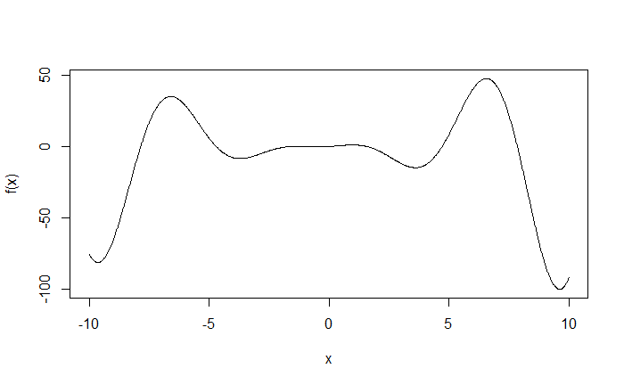

```r
f <- function(x) { (x^2+x)*cos(x) }
min <- -10; max <- 10
curve(f, min, max, n = 1000)
```

## Solving the Problem

Building a genetic algorithm to solve this is simple:

```r
GA <- ga(type = "real-valued", fitness = f, lower = min, upper = max, monitor = FALSE)
```

## Reviewing Results

Let’s see how well the genetic algorithm did:

```r
summary(GA)
```

```
── Genetic Algorithm ───────────────────

GA settings:
Type                  =  real-valued
Population size       =  50
Number of generations =  100
Elitism               =  2
Crossover probability =  0.8
Mutation probability  =  0.1
Search domain =
       x1
lower -10
upper  10

GA results:
Iterations             = 100
Fitness function value = 47.70562
Solution =
           x1
[1,] 6.560561
```

Running a summary shows us the main solution at 6.56, with y valued at 47.70. By default, we used a crossover possibility of 80% and a mutation probability of 10%. The mutation rate seems a bit high for a default, but it did lead us to an answer. Now let’s check the convergence rate:

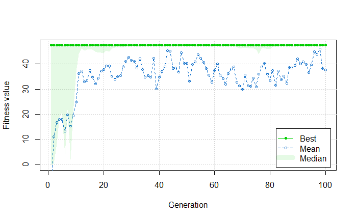

```r
plot(GA)
```

Finally, let’s plot the best result. ga is an R4 class so we use the `@` operator to access properties on the class. The properties we are interested in are `solution` and `fitnessValue`. Because our single variable is a real value, we can plot the solution value and fitness score as the x and y variables, respectively.

```r
curve(f, min, max, n = 1000)
points(GA@solution, GA@fitnessValue, col = 2, pch = 19)
```

[output not shown]